# Analysis

Bailey Kretzler

4/20/2021

## Team 5

First lets read in the data, view it and create a column for the ratio of citations to views

```r
dat <- read.csv("plos_compbio.csv")

colnames(dat)
```

```
##  [1] "DOI"                   "title"                 "year"
##  [4] "num_citations"         "num_views"             "document_type"
##  [7] "num_authors"           "num_references"        "num_figures"
## [10] "num_equations"         "num_countries"         "num_words_title"
## [13] "num_words_abstract"    "prop_words_abs"        "prop_simple_words_abs"
## [16] "first_au_F"            "last_au_F"
```

```r
dat$ratio <- dat$num_citations/dat$num_views

unique(dat$document_type)
```

```
## [1] "Article"          "Editorial"        "Review"           "Erratum"
## [5] "Note"             "Conference Paper" "Letter"           "Short Survey"
```

Great, now that we have done that let’s do some analysis.

*Questions*

- Does the number of authors and countries involved in the paper change the ratio of view to citations? Or just views? Or just citations?
- Does the proportion of simple words in the abstract increase the number of views, citations, or the ratio of the two?

*Hypothesis*

- More countries and authors will increase the number of views and citations. However, the increase in views may be greater, thus decreasing the ratio of citations:views.
- Proportion of simple words in the abstract will increase the views but have and also the number of citations. The impact on the number of citations will be smaller than that of views, thus decreasing the ratio of citations:views.

*Analysis*

- We will use a randomization to assess the relationship of views, citations, and the ratio to number of authors and countries associated with the paper
- We will also use a generalized linear model to assess the relationship of views, citations, and the ratio to the proportion of simple words MAYBE SKIP THIS
- We will only use articles and reviews for this analysis

```r
#---------------------------------------------------------#
#                      subsetting data
#---------------------------------------------------------#

condensed <- dat[which(dat$document_type == "Review"|dat$document_type == "Article"),] # only pull out the articles or reviews

#check with unique

unique(condensed$document_type)
```

```
## [1] "Article" "Review"
```

```r
colnames(condensed)
```

```
##  [1] "DOI"                   "title"                 "year"
##  [4] "num_citations"         "num_views"             "document_type"
##  [7] "num_authors"           "num_references"        "num_figures"
## [10] "num_equations"         "num_countries"         "num_words_title"
## [13] "num_words_abstract"    "prop_words_abs"        "prop_simple_words_abs"
## [16] "first_au_F"            "last_au_F"             "ratio"
```

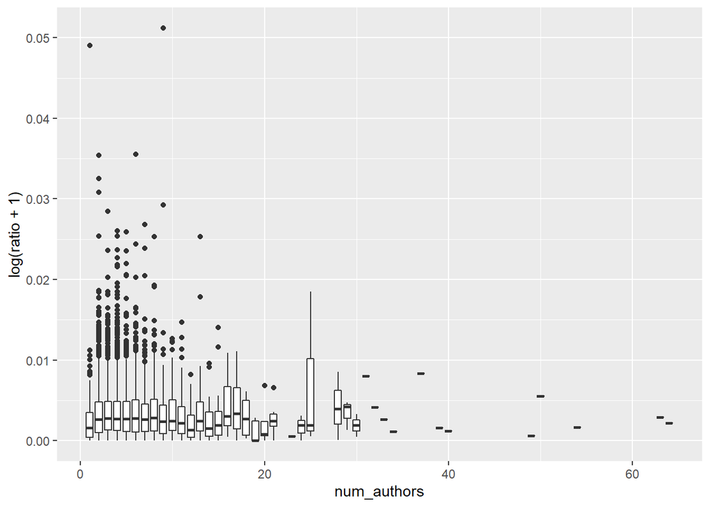

```r
#---------------------------------------------------------#
#                      exploratory plots
#---------------------------------------------------------#

library(ggplot2)

ggplot() + geom_boxplot(data = condensed,
                      aes(x = num_authors, y =log(ratio + 1), group = num_authors))
```

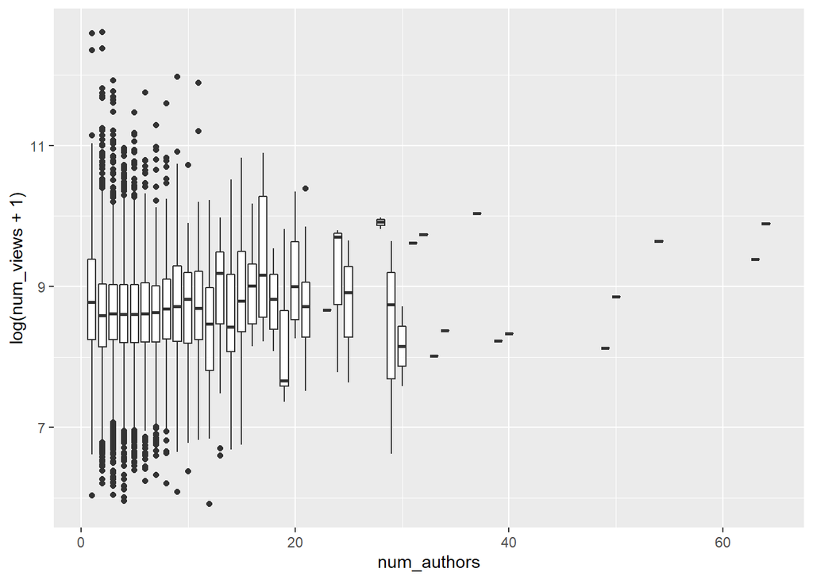

```r
ggplot() + geom_boxplot(data = condensed,
                      aes(x = num_authors, y = log(num_views + 1),
                          group = num_authors))
```

```r
#---------------------------------------------------------#
#                      functions
#---------------------------------------------------------#

#----------------------------------------------------------
#FUNCTION: getMet
#Description: calculate metric for randomization test
#Inputs: 2 column data frame for regression, column ID for parameters to analyze
#Outputs: regression slope
#----------------------------------------------------------
getMet <- function(z = NULL, P1 = 3, P2 = 2) {
  if(is.null(z)){
        xVal <- c(rep("control",10), rep("treatment",10))
        yVal <- rnorm(20) +10*rnorm(20)
        z <- data.frame(ID = seq_along(xVal),
                          x = xVal,
                          y = yVal)

  }

  . <- aov(z[,P1]~z[,P2]) # use anova to get p
  . <- summary(.)
  met <- .[[1]][1,5] #set metric = to the p



  return(met)

} #end of getMet
#----------------------------------------------------------

#a =summary(aov(df$Gs ~df$Water))

#getMet()


#----------------------------------------------------------
#FUNCTION: shuffleDat
#Description: randomize data for a regression
#Inputs: 3 column data frame (ID, x, y)
#Outputs: 3 column data frame (ID, x, y) - reshuffled
#----------------------------------------------------------
shuffleDat <- function(z = NULL, P1 = 3, P2 = 2) {
            if(is.null(z)){
                  xVal <- c(rep("control",10), rep("treatment",10)) # change x to a categorical
                  yVal <- rnorm(20) +10*rnorm(20)
                  z <- data.frame(ID = seq_along(xVal),
                                  x = xVal,
                                  y = yVal)}

    z[,P1] <- sample(z[,P1]) # change to reshuffle specified column


  return(z)

} #end of shuffleDat
#----------------------------------------------------------

#shuffleDat()

#----------------------------------------------------------
#FUNCTION: getP
#Description: obtain p value from simulation
#Inputs: list of observed metric and vector of simulated metrics
#Outputs: upper and lower tail prob value
#----------------------------------------------------------
getP <- function(z = NULL) {
  if(is.null(z)){
    z <- list(rnorm(1), rnorm(1000))}

  plower <- mean(z[[2]] <= z[[1]]) # calculated the proportion when simulated value is less than or equal to observed value
  pupper <-  mean(z[[2]] >= z[[1]]) # calculated the prop when sim is greater than or equal to obs



  return(c(pL = plower, pU = pupper))

} #end of getP
#----------------------------------------------------------

#getP()

#----------------------------------------------------------
#FUNCTION: plotRan
#Description: create ggplot of histogram of simulated values
#Inputs: liat of observed metric and vector of simulated metrics
#Outputs: saved ggplot histogram
#----------------------------------------------------------
plotRan  <- function(z = NULL) {
    if(is.null(z)){
      z<- list(rnorm(1), rnorm(1000))
    }
  df <- data.frame(ID = seq_along(z[[2]]), simX = z[[2]])
  p1 <- ggplot(data = df, mapping = aes(x=simX))+
    geom_histogram(mapping = aes(fill = I("goldenrod"),
                                 colour = I("black")))+
    geom_vline(aes(xintercept = z[[1]], col = "blue"))
  print(p1)

} #end of plotRan
#----------------------------------------------------------

#plotRan()


library(agricolae)


a <- HSD.test(aov(data = condensed,num_views~num_authors), "num_authors",group = TRUE, console = TRUE)[[5]]
```

```
##
## Study: aov(data = condensed, num_views ~ num_authors) ~ "num_authors"
##
## HSD Test for num_views
##
## Mean Square Error:  118529405
##
## num_authors,  means
##
##    num_views       std    r   Min    Max
## 1  13957.170 29501.531  182   417 295070
## 2   8146.067 14286.506 1348   493 298911
## 3   7483.395  9606.494 1595   419 150888
## 4   7262.135  6765.297 1358   386  57801
## 5   7381.396  7767.758  978   597  95412
```

[output cut: 82 more lines]

```r
a$num_authors <- rownames(a)

View(a)

unique(condensed$num_authors)
```

```
##  [1]  1  2  4  3  5  7  6 10 11  9  8 16 15 13 12 17 18 37 31 21 28 14 20 24 32
## [26] 50 54 63 64 29 40 34 49 19 39 30 25 33 23
```